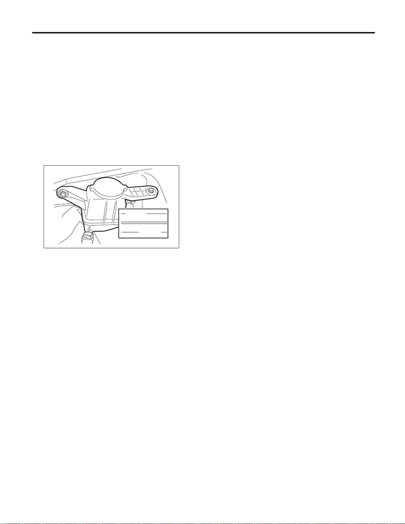

PS-83

Power Steering Fluid

POWER ASSISTED SYSTEM (POWER STEERING)

11.Power Steering Fluid

A: SPECIFICATION

Recommended power steering fluid:

SUBARU ATF or ATF DEXRON III

B: INSPECTION

taminated, drain it and refill with new fluid.

2) Check the joints and units for oil leakage. If any oil leaks are found, repair or replace the applicable part.

3) Inspect the fluid level of the reservoir - tank assembly with vehicle on level surface and engine stopped.

If the level is at “MIN.” point or below, add fluid to keep the level in the specified range of the indicator. If at

“MAX.” point or above, drain fluid by using a syringe or the like.

(1) When the power steering fluid temperature is 20°C (68°F), check the fluid level on the “COLD” side.

(2) When the power steering fluid temperature is 80°C (176°F), check the fluid level on the “HOT” side.

C: REPLACEMENT

1) Lift up the vehicle.

2) Drain the power steering fluid.

(1) Remove the pipe joint of the gearbox, and connect the vinyl hose to the pipe and the joint.

(2) Discharge the fluid by turning the steering wheel fully clockwise and counterclockwise.

3) Add the specified fluid to the reservoir - tank assembly at “MAX” level.

4) Continue to turn the steering wheel slowly from lock to lock until the bubbles stop appearing on oil surface

while keeping the fluid at the level in the step 3).

tered, leave it for about half an hour and then repeat step 4) again.

6) Start the engine and let it idle.

7) Continue to turn the steering wheel slowly from lock to lock again until the bubbles stop appearing on oil

surface, while keeping the fluid at the level in step 3).

Normally bubbles will stop appearing after turning the steering wheel from lock to lock three times.

8) In case bubbles do not stop appearing in the tank, leave it for about half an hour and then repeat from step

3) again.

9) Lower the vehicle, and then idle the engine.

10) Continue to turn the steering wheel from lock to lock until the bubbles stop appearing and change of the

fluid level is within 3 mm (0.12 in).

11) In case the following happens, leave it about half an hour and then perform step 7) to 10) again.

(1) The fluid level changes by 3 mm (0.12 in) or more.

(2) Bubbles remain on the upper surface of the fluid.

(3) Grinding noise is generated from oil pump.

12) Check the fluid leakage after turning steering wheel from lock to lock with engine running.

HOT MAX

COLD MAX

HOT MIN

COLD MIN

PS-01716